# DE CARLO

Mégane

2023-04-20

#### *Data wind speed 10m (m/s)*:

→ Azur buoy (model) - 2009-2022  
→ EOL buoy (model) - 2009-2022

Frequency : Hourly  
Unity : m/s

### **Histogram of wind speed distribution : pelagic (Azur buoy) vs coastal (EOL buoy)**

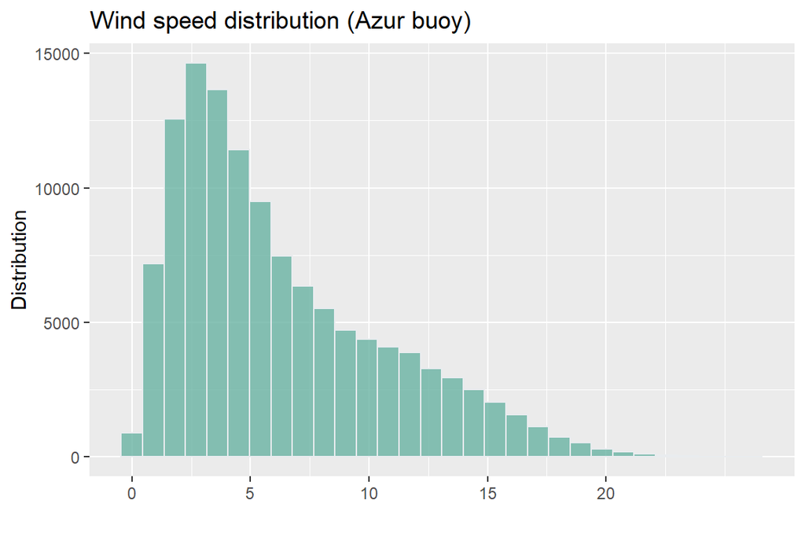

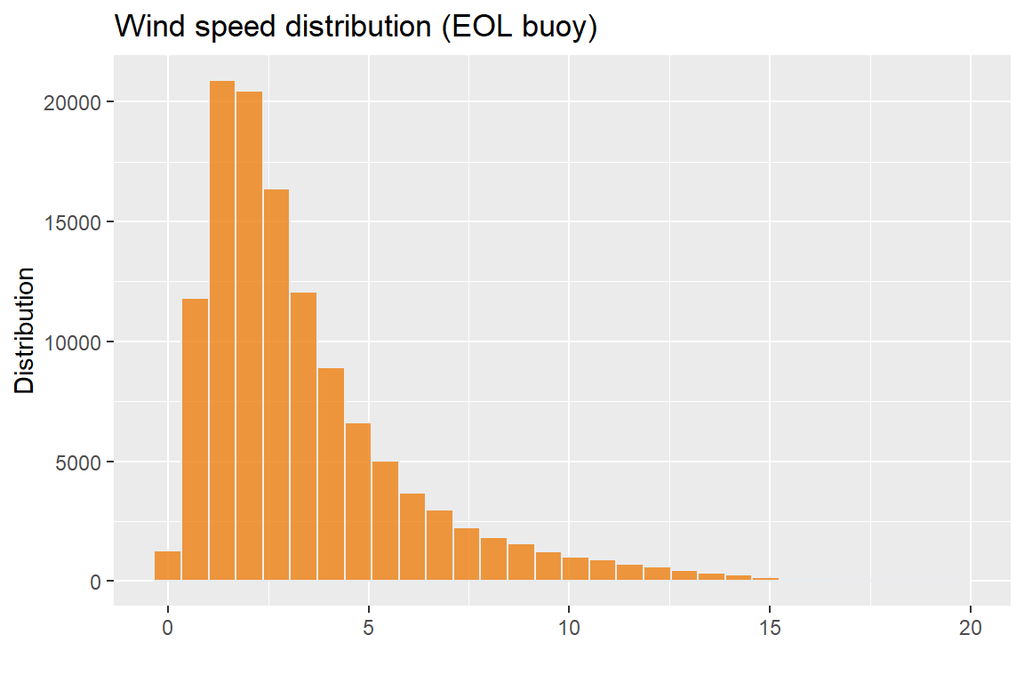

### **Annual wind speed evolution (2009-2022) : EOL buoy**

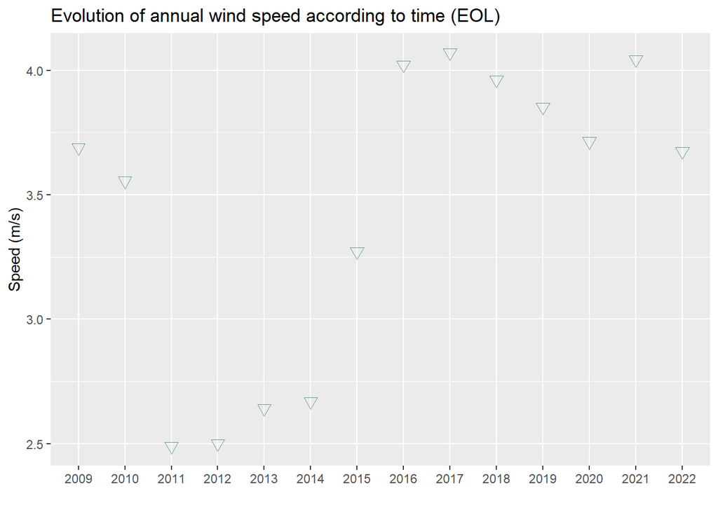

#### *Data pCO2 water SOMLIT (µatm)*:

period : jan.2007 - dec.2022

Frequency : Weekly (every tuesday at 09 AM)  
Unity : µatm

→ Interpolation temperature & salinity :

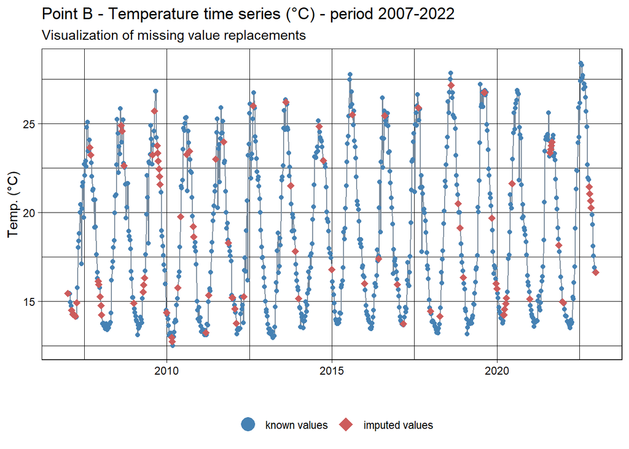

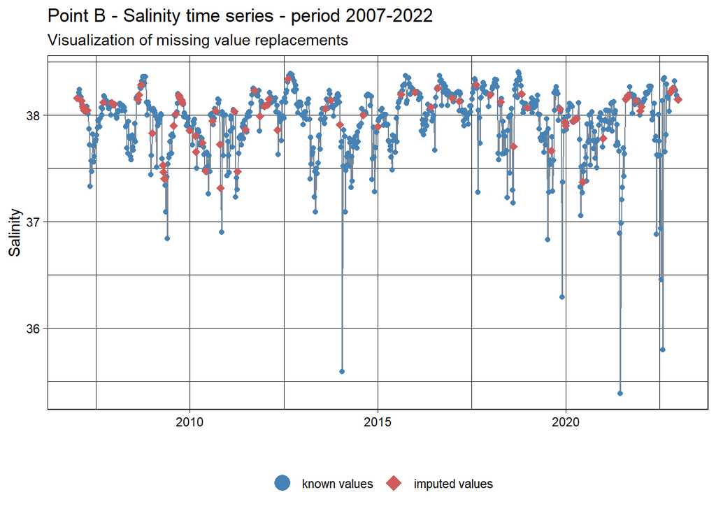

→ Interpolation pCO2 water :

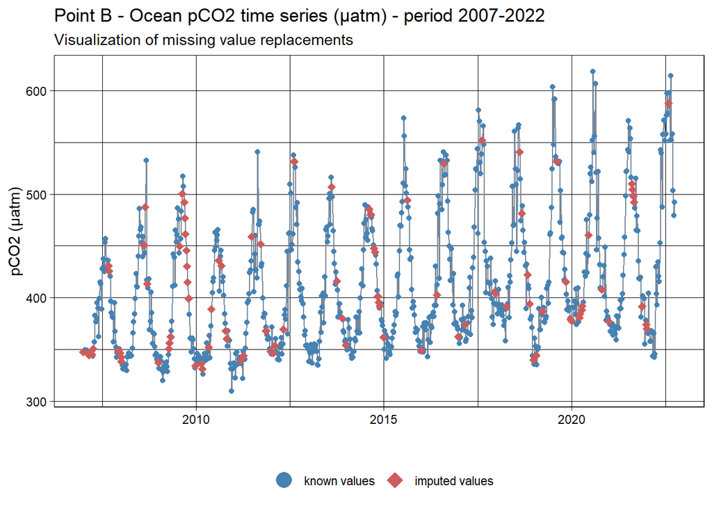

→ Interpolation AT & CT :

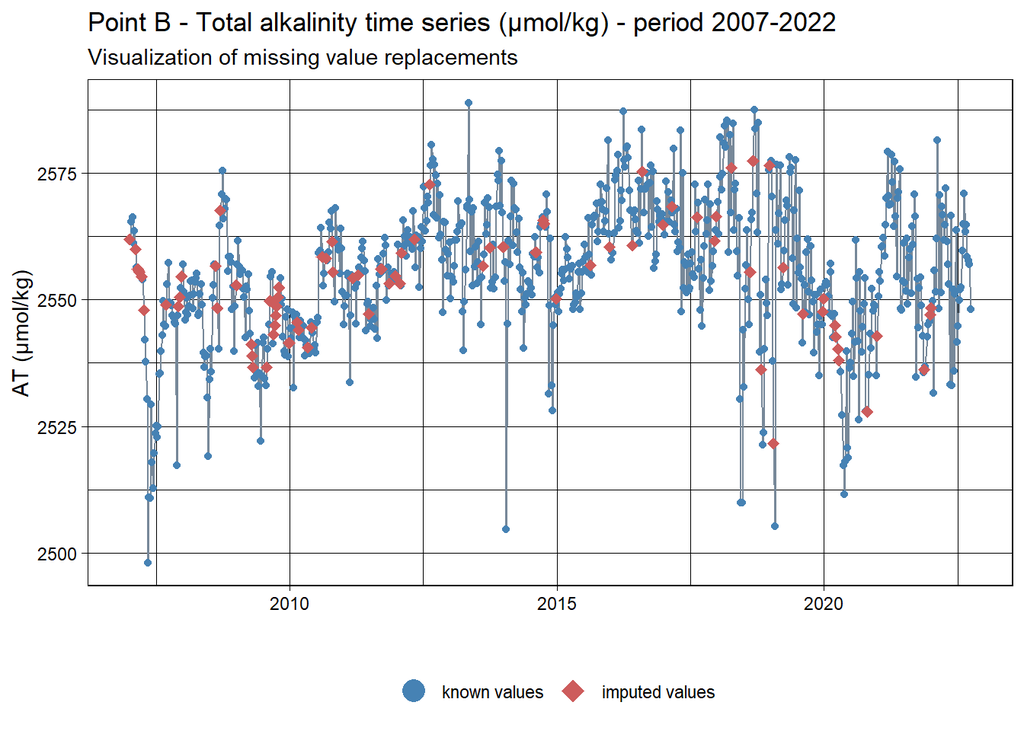

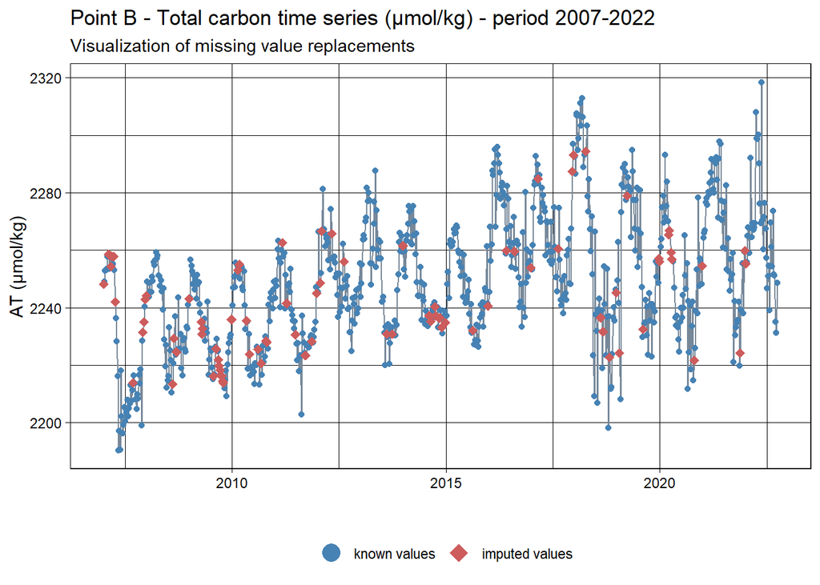

→ Interpolation pH & pH(18) :

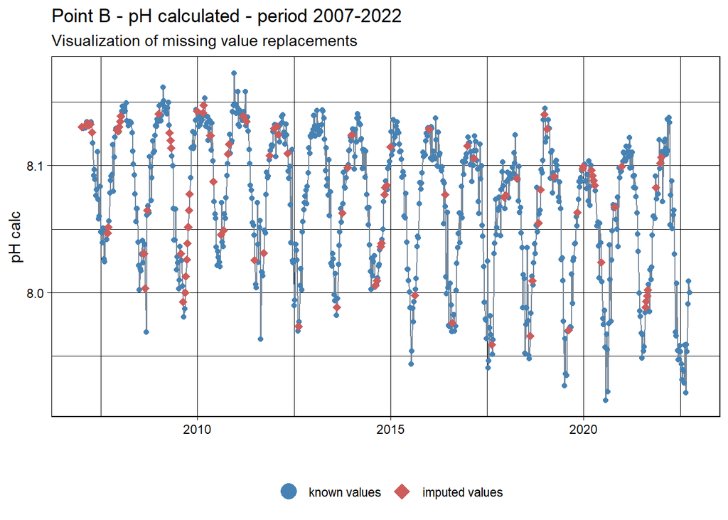

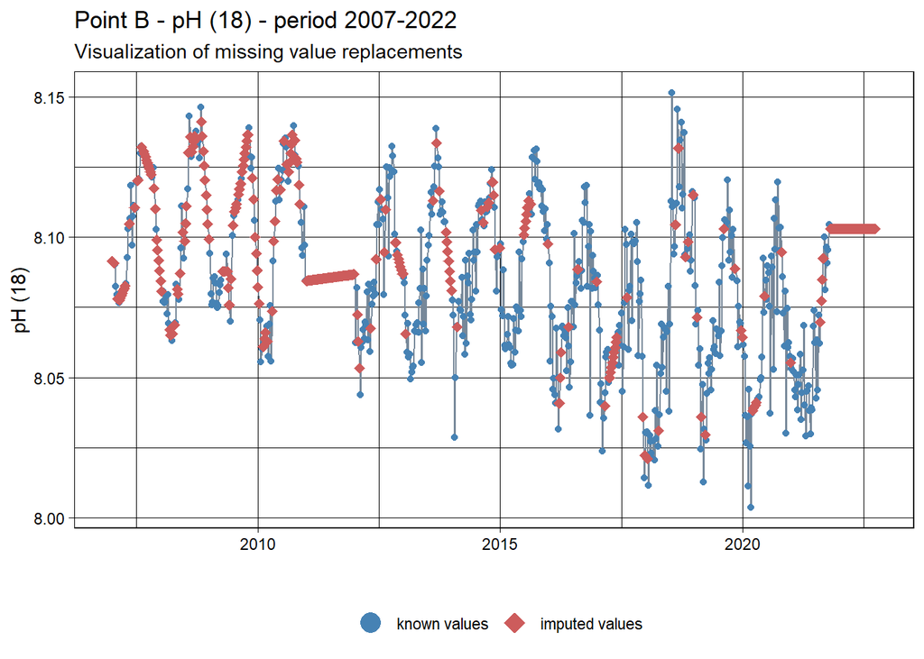

#### *Data pCO2 air (µatm)*:

period : jan.2007 - feb.2022

Frequency : Hourly Unity : µatm

→ Corse Ersa (40m) - 2013-2020  
→ Plateau Rosa (10m) - 2007-2022  
→ Lampedusa (10m) - 2006-2022

###### Interpolation of atmospheric pCO2 :

→ Cross interpolation between 3 atmospheric sites : Corsica x Lampedusa x Plateau Rosa

→ Then, linear interpolation :  
*(+ conversion dry mol fraction into µatm)*

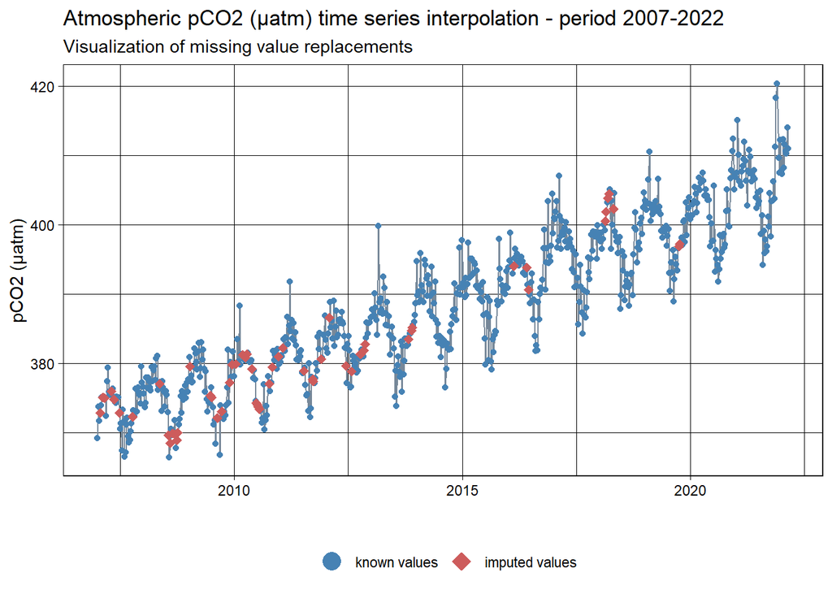

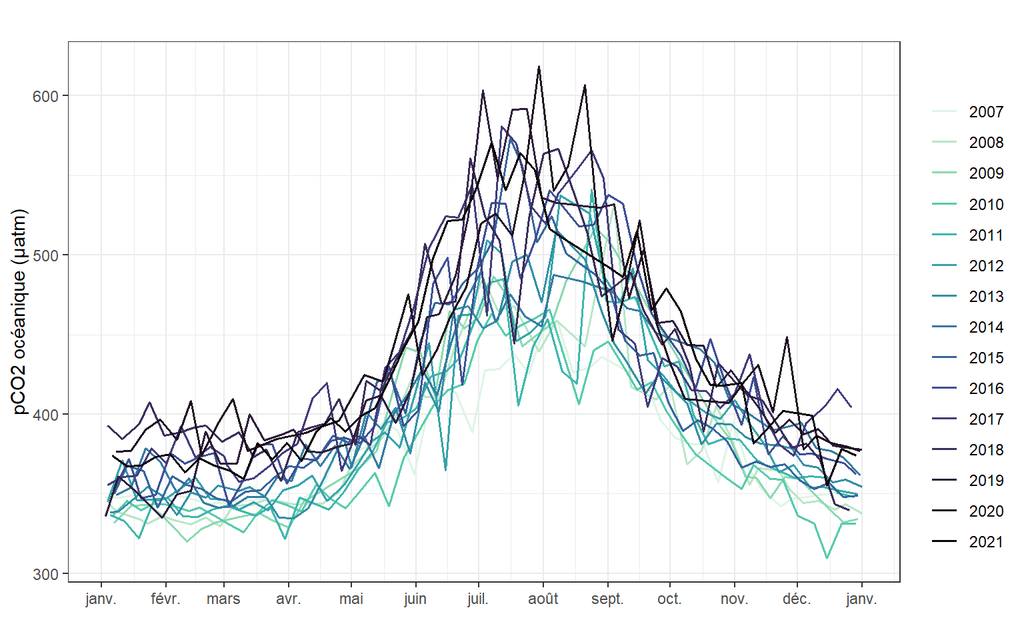

→ Calculation of NpCO<sub>2</sub> & TpCO<sub>2</sub> :

*NpCO<sub>2</sub> = non-temperature effects on pCO<sub>2</sub> water variations*

*TpCO<sub>2</sub> = only temperature effects on pCO<sub>2</sub> water variations*

→ Calculation of deltas :

- delta pCO<sub>2</sub>(T) = temperature effects = pCO<sub>2</sub> water - NpCO<sub>2</sub>
- delta pCO<sub>2</sub>(bio) : biological effects = pCO<sub>2</sub> water - TpCO<sub>2</sub>

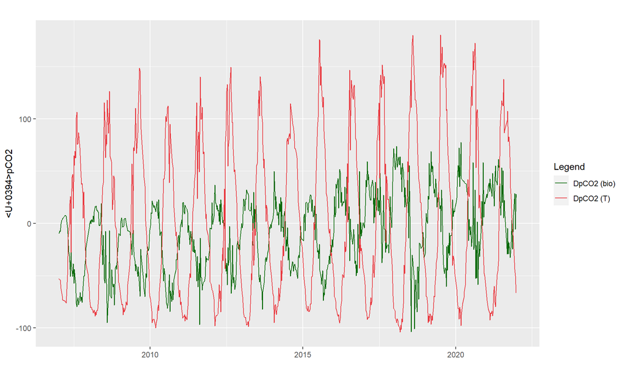

→ Atmospheric and water pCO<sub>2</sub> (µatm) according to time (2007-2022) :

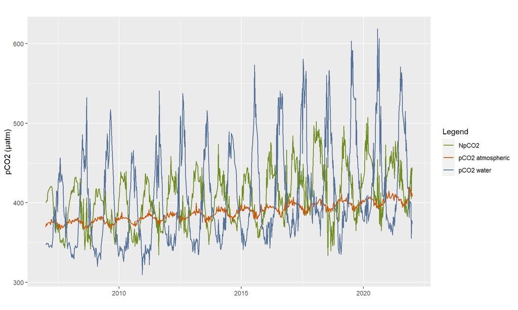

## Air-surface CO<sub>2</sub> flux

### Flux calculation

→ **negative values = flux into the ocean**

Method used : Wanninkhof (2014)

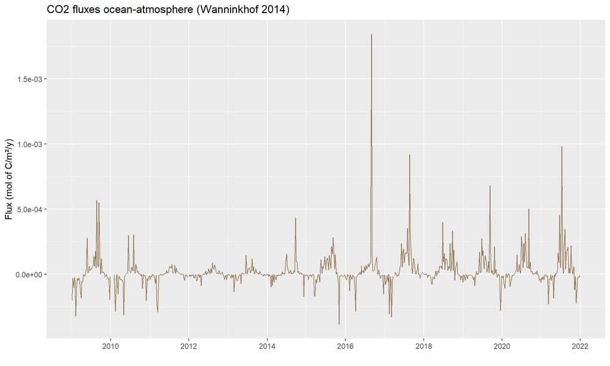

Method used : Wanninkhof (1992)

Formulas :

- K600 = 0.266 * U²
- SC = 2073.1 - (125.62 * T) + (3.6276 * T²) - (0.043219 * T^3)
- k = K600 * (SC/600)^0.5 (cm/h)
- K0 = Henry’s constant (seacarb)

Final formula : F = k * K0 * ΔpCO2

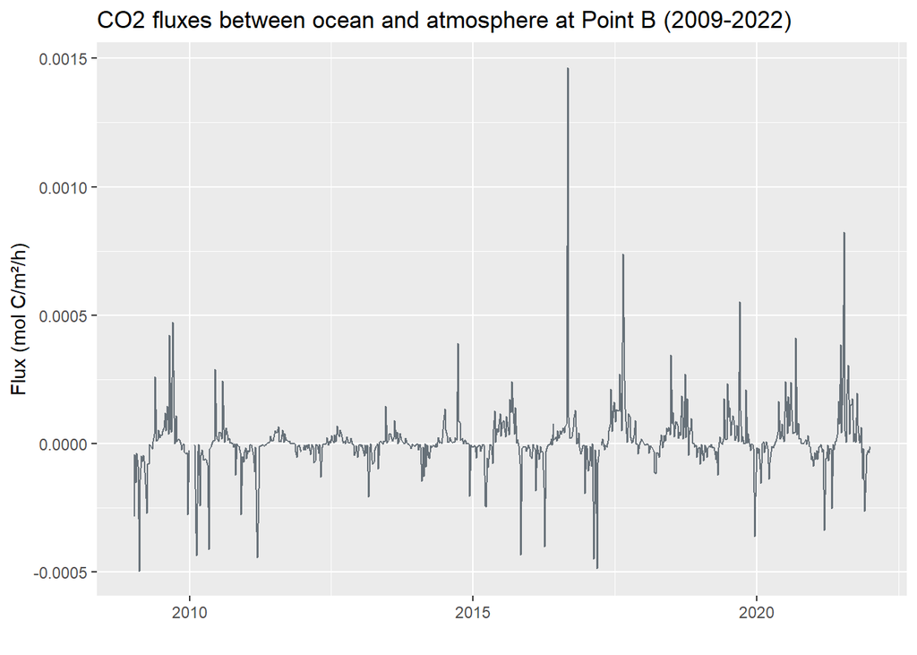

Method used : David T. Ho (2023)

Formulas :

- K600 = 0.143 * U²
- SC = 2073.1 - (125.62 * T) + (3.6276 * T²) - (0.043219 * T^3)  
  or gas_schmidt() function of marelac package (same result)
- k = K600 * (SC/600)^0.5 (cm/h)
- K0 = Henry’s constant (seacarb) Final formula : F = k * K0 * ΔpCO2

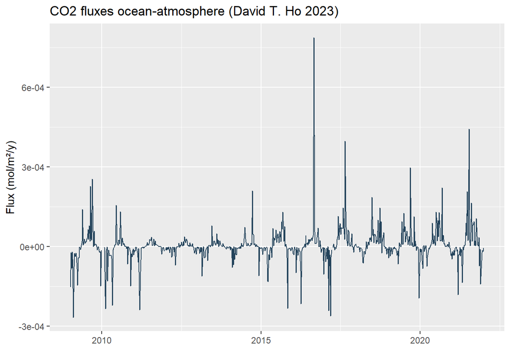

Summary table of 3 calculation methods results (Wanninkhof 1992 & 2014, David T. Ho 2023) :

```
##          Datetime   Flux_wan_92 Flux_wan_2014  Flux_Ho_2023
## 104    2010-12-28 -1.641566e-05 -1.118742e-05 -8.824961e-06
## 105    2011-01-04 -5.727814e-05 -3.957748e-05 -3.079238e-05
## 106    2011-01-11 -2.691117e-05 -1.805907e-05 -1.446728e-05
## 107    2011-01-18 -3.037721e-05 -2.001301e-05 -1.633061e-05
## 108    2011-01-25 -6.022485e-06 -3.984675e-06 -3.237652e-06
## 109    2011-02-01 -5.766990e-06 -3.837391e-06 -3.100299e-06
## 110    2011-02-08 -1.425121e-05 -9.389782e-06 -7.661364e-06
## 111    2011-02-15 -4.195267e-05 -2.780229e-05 -2.255350e-05
## 112    2011-02-22 -1.094245e-04 -7.139129e-05 -5.882597e-05
## 113    2011-03-01 -1.269549e-05 -8.427802e-06 -6.825019e-06
## 114    2011-03-08 -3.430130e-04 -2.259529e-04 -1.844017e-04
## 115    2011-03-15 -4.434224e-04 -2.898410e-04 -2.383812e-04
## 116    2011-03-22 -1.759135e-04 -1.186552e-04 -9.457005e-05
## 117    2011-03-29 -1.063856e-05 -7.152741e-06 -5.719224e-06
```

[output cut: 720 more lines]

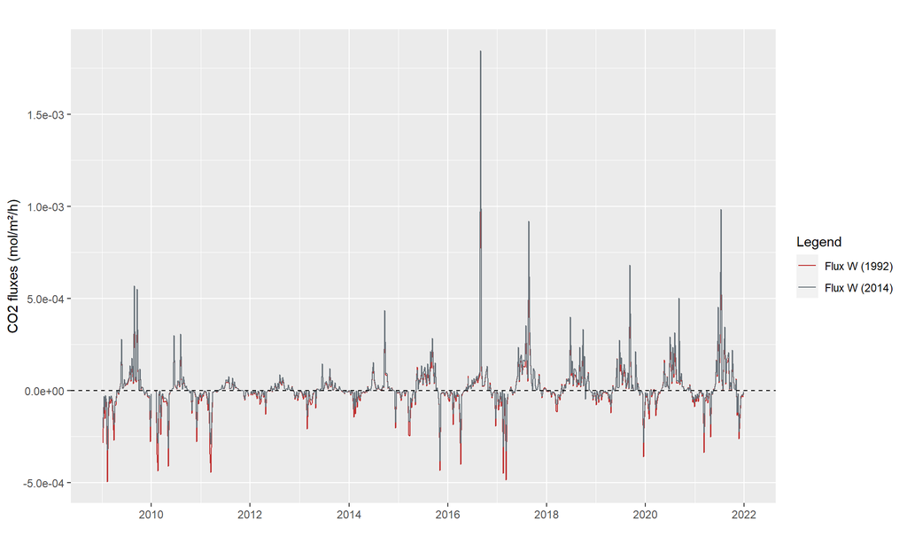

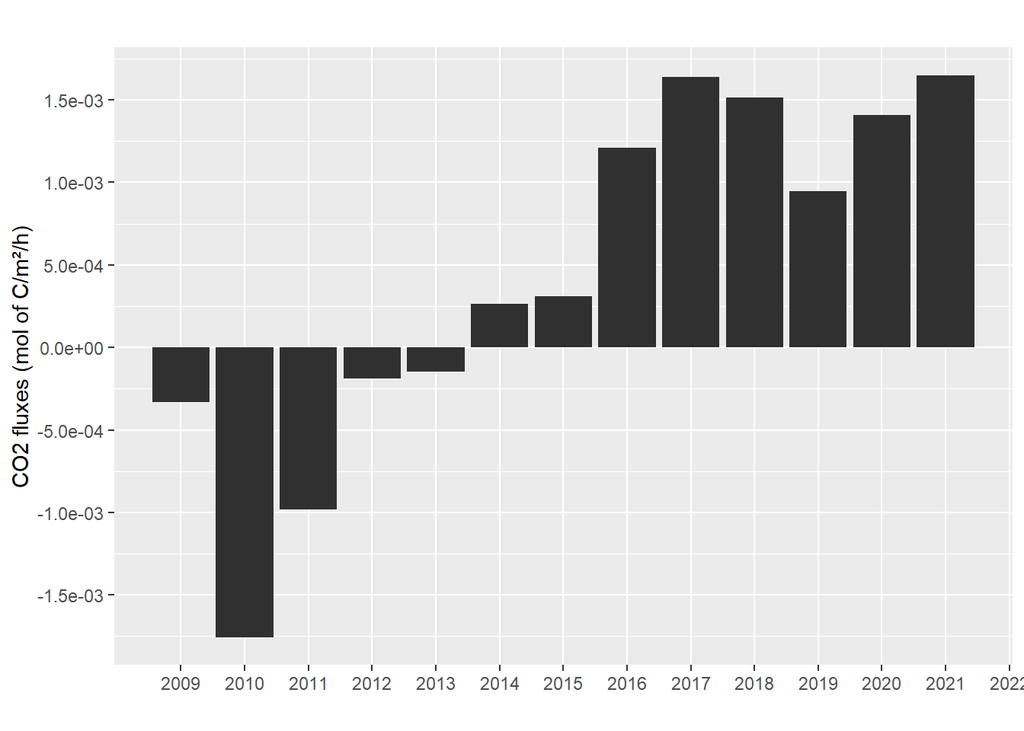

## Comparison with DE CARLO results (jan.2007 - oct.2011)

Point B : 2009-2011, so comparison for 2009-2011 period

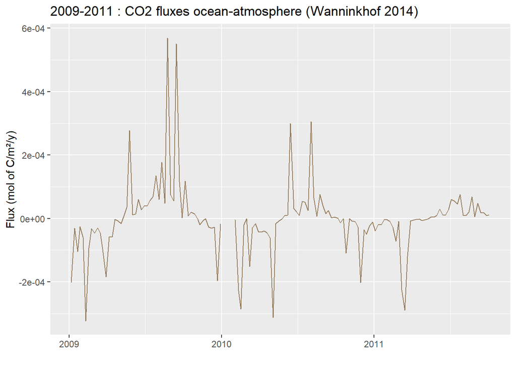

De Carlo (2007-2011) :  
- average hourly flux : -2.19e-05  
- annualized flux (by year) : 1.91e-01  
- maximum hourly flux (winter) : -4.57e-04  
- minimum hourly flux (summer): 4.29e-04

De Carlo (01/06/2009 - 10/04/2011) :  
- average hourly flux : -2.77e-05  
- annualized flux (by year) : 2.42e-01  
- maximum hourly flux (winter) : -4.57e-04  
- minimum hourly flux (summer): 4.29e-04

Point B (01/06/2009 - 10/04/2011) :  
- average hourly flux : -1.65e-06  
- annualized flux (by year) : 1.45e-02 - maximum hourly flux (winter) : -3.23e-04  
- minimum hourly flux (summer) : 5.70e-04